# Análise Exploratória dos municípios que adotaram política de isenção de tarifa no transporte público

Thais Fernandes Pereira

Julho de 2021

**1. Apresentação do objeto de estudo, recorte empírico e municípios estudados**

| UF | Cidade | Ano da Implementação | Classe Populacional | PIB Per Capta | Renda Per Capta Média | % de Pobres | Prosperidade Social | Taxa de Atividade 18 anos ou mais | Taxa de Urbanização | % de vulneráveis à pobreza que gastam mais de uma hora até o trabalho | % da população ocupada vulnerável à pobreza que retorna diariamente do trabalho | Índice de Gini | Índice de Theil | IDHM | IDHM Educação | IDHM Renda | IDHM Longevidade | Indice de Vulnerabilidade Social | IVS Infraestrutura Urbana | IVS Capital Humano | IVS Renda e Trabalho |
| --- | --- | --- | --- | --- | --- | --- | --- | --- | --- | --- | --- | --- | --- | --- | --- | --- | --- | --- | --- | --- | --- |
| MG | Monte Carmelo | 1994 | 20.000 Até 50.000 | 2365449 | 689.45 | 0.0685 | Muito Alto | 0.6924 | 0.876081447172944 | 0.0036 | 0.0500115041101048 | 0.49 | 0.43 | Alto | Médio | Alto | Muito Alto | Baixa | Muito Baixa | Média | Baixa |
| MG | Abaeté | 1997 | 20.000 Até 50.000 | 2128643 | 707.24 | 0.0669 | Alto | 0.659 | 0.868400176289114 | 0.0105 | 0.0495330722554547 | 0.54 | 0.54 | Médio | Baixo | Alto | Muito Alto | Baixa | Baixa | Média | Média |
| SP | Potirendaba | 1998 | 10.000 Até 20.000 | 2994939 | 785.96 | 0.0295 | Muito Alto | 0.6912 | 0.898698944915528 | 0.0017 | 0.0180865157537008 | 0.4 | 0.28 | Alto | Médio | Alto | Muito Alto | Muito Baixa | Muito Baixa | Baixa | Muito Baixa |
| PR | Faxinal | 2001 | 10.000 Até 20.000 | 2475272 | 612.79 | 0.0794 | Alto | 0.6617 | 0.780863062400392 | 0.005 | 0.0661990609240044 | 0.48 | 0.41 | Médio | Baixo | Médio | Alto | Baixa | Muito Baixa | Alta | Média |
| PR | Ivaiporã | 2001 | 20.000 Até 50.000 | 2561424 | 666.73 | 0.0958 | Muito Alto | 0.6756 | 0.862396278601961 | 0.0076 | 0.0594672336168084 | 0.48 | 0.4 | Alto | Médio | Alto | Muito Alto | Baixa | Muito Baixa | Baixa | Média |
| SP | Agudos | 2003 | 20.000 Até 50.000 | 5951301 | 642.59 | 0.0661 | Muito Alto | 0.6893 | 0.955654037770826 | 0.0068 | 0.0269522222819369 | 0.41 | 0.31 | Alto | Médio | Alto | Muito Alto | Baixa | Baixa | Baixa | Baixa |
| SP | Macatuba | 2004 | 10.000 Até 20.000 | 3672303 | 920.95 | 0.0269 | Muito Alto | 0.6809 | 0.970293375976382 | 0.0072 | 0.0210336188312067 | 0.55 | 0.54 | Alto | Médio | Alto | Muito Alto | Baixa | Média | Baixa | Muito Baixa |
| PR | Wenceslau Braz | 2008 | 10.000 Até 20.000 | 2865264 | 594.42 | 0.1324 | Médio | 0.6419 | 0.803658410197948 | 0.0174 | 0.0725249819717729 | 0.52 | 0.49 | Médio | Baixo | Médio | Alto | Média | Baixa | Alta | Média |
| GO | Aruanã | 2008 | 5.000 Até 10.000 | 2299062 | 654.67 | 0.0901 | Alto | 0.7331 | 0.824172892209178 | 0.0023 | 0.0507341772151899 | 0.51 | 0.46 | Médio | Baixo | Alto | Muito Alto | Baixa | Muito Baixa | Alta | Baixa |
| CE | Eusébio | 2010 | 50.000 Até 100.000 | 4683008 | 623.01 | 0.2203 | Alto | 0.6792 | 1 | 0.0112 | 0.091070163004961 | 0.65 | 0.79 | Alto | Médio | Alto | Alto | Média | Baixa | Alta | Média |

[output cut: 20 more lines]

**2. Localização dos municípios**

O mapa abaixo nos mostra a localização das cidades, os pontos representam os municípios:

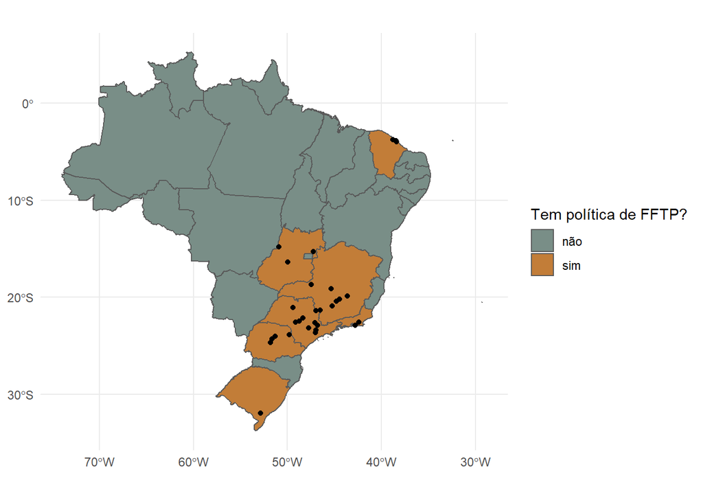

| Região | Qtd. de Municípios |
| --- | --- |
| Sudeste | 19 |
| Sul | 5 |
| Centro-Oeste | 3 |
| Nordeste | 3 |

Dos 27 estados brasileiros, sete possuem algum município que implementou FFTP, Minas Gerais é o estado com mais municípios no Brasil mas o segundo com mais cidades com FFTP, e São Paulo é o segundo com mais municípios e no entando o estado com mais cidades que adotaram a política.

| UF | Qtd. de Municípios |
| --- | --- |
| SP | 9 |
| MG | 8 |
| PR | 4 |
| CE | 3 |
| GO | 3 |
| RJ | 2 |
| RS | 1 |

**3. Dados populacionais**

A média populacional desses municípios é 31 mil habitantes, sendo que há quantidades bem discrepantes, com um máximo de pouco mais de 160 mil, como é o caso de Maricá no Rio de Janeiro, e um mínimo de 7 mil habitantes em Pedro Osório no Rio Grande do Sul (IBGE, 2020). Abaixo podemos visualizar a quantidade de municípios por classe populacional,cerca de 70% dos municípios possuem entre 10 e 50 mil habitante ao passo que não há nenhum município com mais de 500 mil habitantes que tenha adotado a política de FFTP.

| Classe Populacional | Munic.com FFTP | Munic.sem FFTP |
| --- | --- | --- |
| 20.000 Até 50.000 | 11 | 1089 |
| 10.000 Até 20.000 | 9 | 1333 |
| 50.000 Até 100.000 | 4 | 345 |
| 100.000 Até 500.000 | 3 | 273 |
| 5.000 Até 10.000 | 3 | 1195 |

**4. Ano de Implementação da Política de FFTP**

Quase 70% dos municípios que adotaram FFTP o fizeram depois de 2010, seguindo uma tendência mundial, já observada por Klebowski (2019), no entanto, como mostrado na tabela inicial deste relatório, há três casos de municípios que adotaram a política ainda nos anos 1990, como Monte Carmelo (MG) que adotou em 1994, Potirendaba (SP) em 1998 e Abaeté (MG)em 1997.

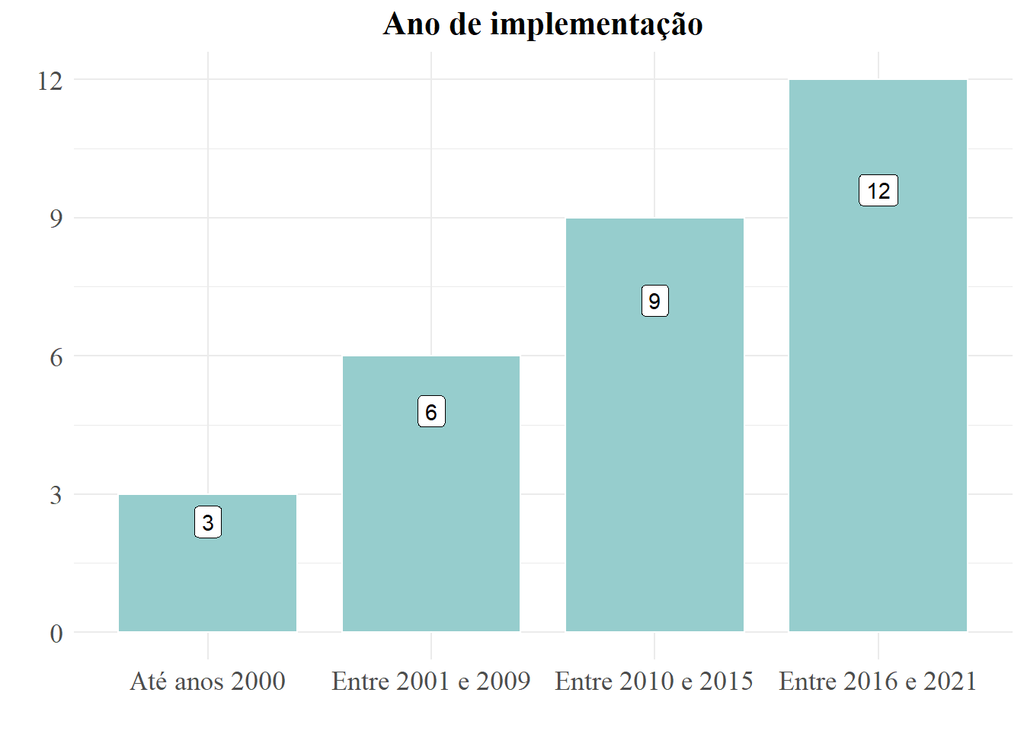

**5. Taxa de Urbanização**